# Сеетевые технологии

Лабораторная работа №7

Тойчубекова Асель Нурлановна

kulyabov-ds@rudn.ru

Российский университет дружбы народов

2025-12-06

# Информация

## Докладчик

- Тойчубекова Асель Нурлановна
- Студент 3 курса
- факультет физико-математических и естественных наук
- Российский университет дружбы народов им. П. Лумумбы
- 1032235033@rudn.ru

# Цель работы

## Цель работы

Целью данной лабораторной работы является получение навыков настройки службы DHCP на сетевом оборудовании для распределения адресов IPv4 и IPv6.

# Задание

## Задание

1. Настроить DHCP в случае IPv4
2. Настроить DHCP в случае IPv6

# Теоретическое введение

## Теоретическое введение

В современных компьютерных сетях для обеспечения корректной работы устройств необходима настройка сетевых параметров, таких как IP-адрес, маска подсети, шлюз по умолчанию и адреса DNS-серверов. Ручная конфигурация этих параметров на каждом узле является трудоёмкой и подверженной ошибкам, поэтому в сетях IPv4 и IPv6 широко применяется автоматическая настройка с использованием протоколов динамической конфигурации.

## Теоретическое введение

Для сетей IPv4 таким механизмом является DHCP (Dynamic Host Configuration Protocol). Он реализует модель клиент–сервер и обеспечивает автоматическое распределение IP-адресов из заранее определённого пула. Передача DHCP-сообщений осуществляется через протокол UDP: сервер принимает запросы клиентов на порту 67 и отправляет ответы на порт 68. Процесс аренды адреса включает обмен сообщениями DHCPDISCOVER, DHCPOFFER, DHCPREQUEST и DHCPACK.

## Теоретическое введение

В сетях IPv6 применяются два механизма автоматической настройки: SLAAC (Stateless Address Autoconfiguration) и DHCPv6. SLAAC позволяет узлу самостоятельно сформировать IPv6-адрес на основе информации, поступающей от маршрутизатора в виде ICMPv6-сообщений Router Advertisement. Проверка уникальности созданного адреса выполняется с помощью процедуры обнаружения дубликатов (DAD). Однако SLAAC предоставляет только базовые параметры, поэтому для получения дополнительной информации может использоваться DHCPv6.

# Выполнение лабораторной работы

## Настройка DHCP в случае IPv4

Запустим GNS3 VM и GNS3. Создадим новый проект. В рабочем пространстве разместим и соединим устройства в соответствии с топологией данной в лабораторной работе. Изменим название устройств, указав наш логин и счетный номер.

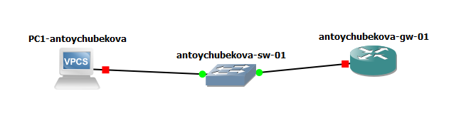

Топология моделируемой сети

## Настройка DHCP в случае IPv4

Включим захват трафика на соединении между коммутатором sw-01 и маршрутизатором gw-01.

[figure not shown]

Захват трафика

## Настройка DHCP в случае IPv4

На маршрутизаторе перейдем в режим конфигурирования, изменим имя устройства и доменное имя, заменим системного пользователя, заданного по умолчанию, на нашего пользователя.

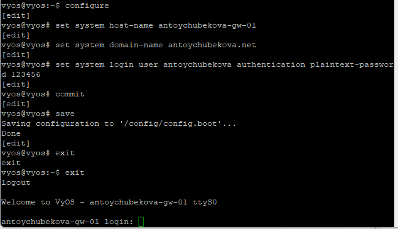

Изменение системного пользователя

## Настройка DHCP в случае IPv4

Зайдем под нашим пользователем и удалим пользователя vyos.

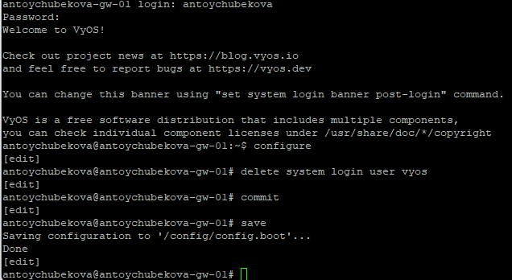

Удаление пользователя vyos

## Настройка DHCP в случае IPv4

На маршрутизаторе под созданным пользователем перейдем в режим конфигурирования и настроим адресацию IPv4.

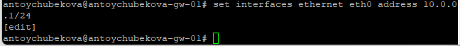

Настройка адресации IPv4

## Настройка DHCP в случае IPv4

Добавим конфигурацию DHCP-сервера на маршрутизаторе.Создадим разделяемую сеть (shared-network-name) с названием antoychubekova.

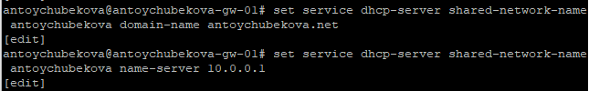

Добавление конфигурации DHCP-сервера

## Настройка DHCP в случае IPv4

Далее создадим подсеть (subnet) с адресом 10.0.0.0/24, задан диапазон адресов (range) с именем hosts, содержащий адреса 10.0.0.2–10.0.0.253.

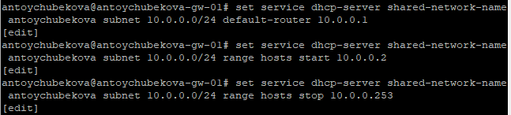

Добавление конфигурации DHCP-сервера

## Настройка DHCP в случае IPv4

Сохраним наши изменения.

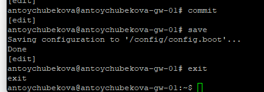

Сохранения изменений

## Настройка DHCP в случае IPv4

Просмотрим статистики DHCP-сервера и выданных адресов. Мы видим, что сводную статистику DHCP-сервера: размер пула адресов, количество выданных аренд (leases), доступные адреса и процент использования пула. В представленном выводе пул содержит 252 адреса, все они доступны, аренды отсутствуют (0% использования).

Также видим выданные IP-адреса, MAC-адреса клиентов, состояние аренды, время начала и окончания, оставшееся время, пул и имя хоста. В данном выводе аренды отсутствуют, поэтому таблица пуста.

## Настройка DHCP в случае IPv4

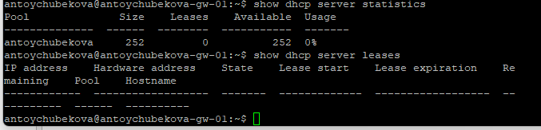

Статистика DHCP-сервера

## Настройка DHCP в случае IPv4

Настроим оконечное устройство PC1.

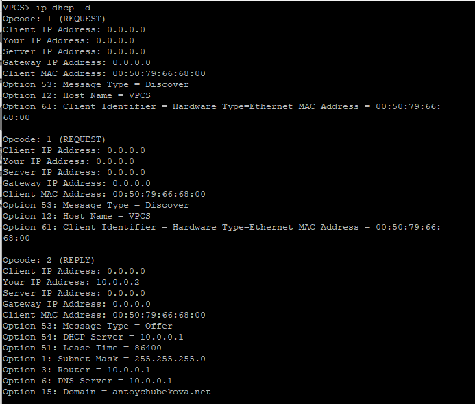

Настройка оконечного устройства

## Настройка DHCP в случае IPv4

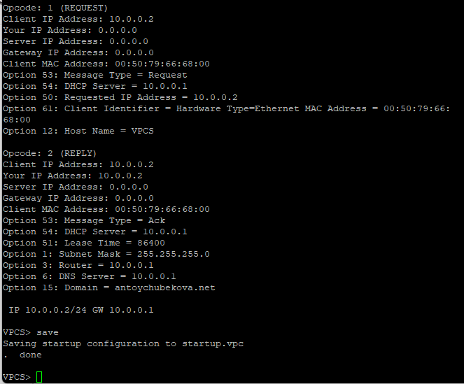

Настройка оконечного устройства

## Настройка DHCP в случае IPv4

Проверим конфигурацию IPv4 на узле, пропингуем маршрутизатор. Мы видим, что все корректно работает.

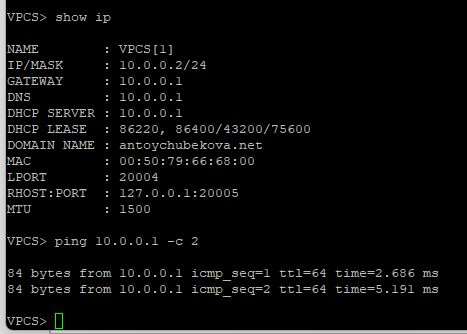

Проверка конфигурации IPv4

## Настройка DHCP в случае IPv4

На маршрутизаторе вновь посмотрим статистику DHCP-сервера и выданные адреса.

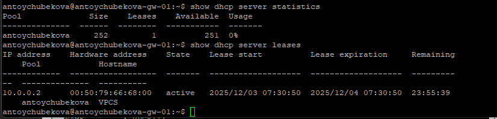

Статистика DHCP-сервера

## Настройка DHCP в случае IPv4

На маршрутизаторе посмотрим журнал работы DHCP-сервера.

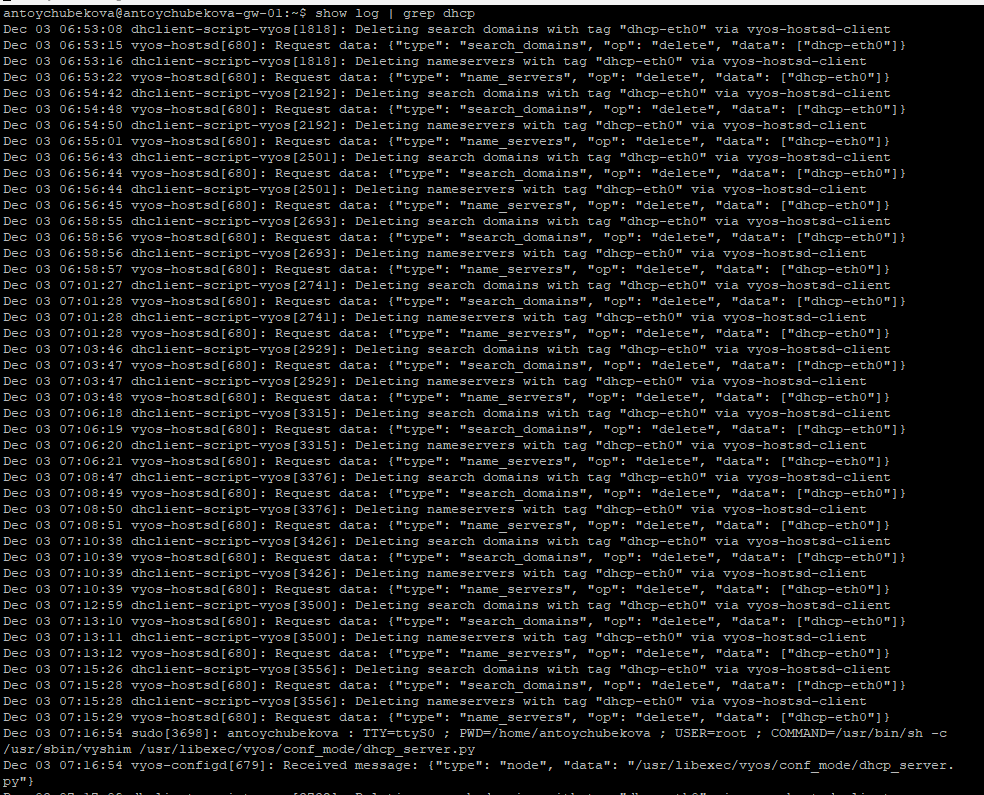

Журнал работы DHCP-сервера

## Настройка DHCP в случае IPv4

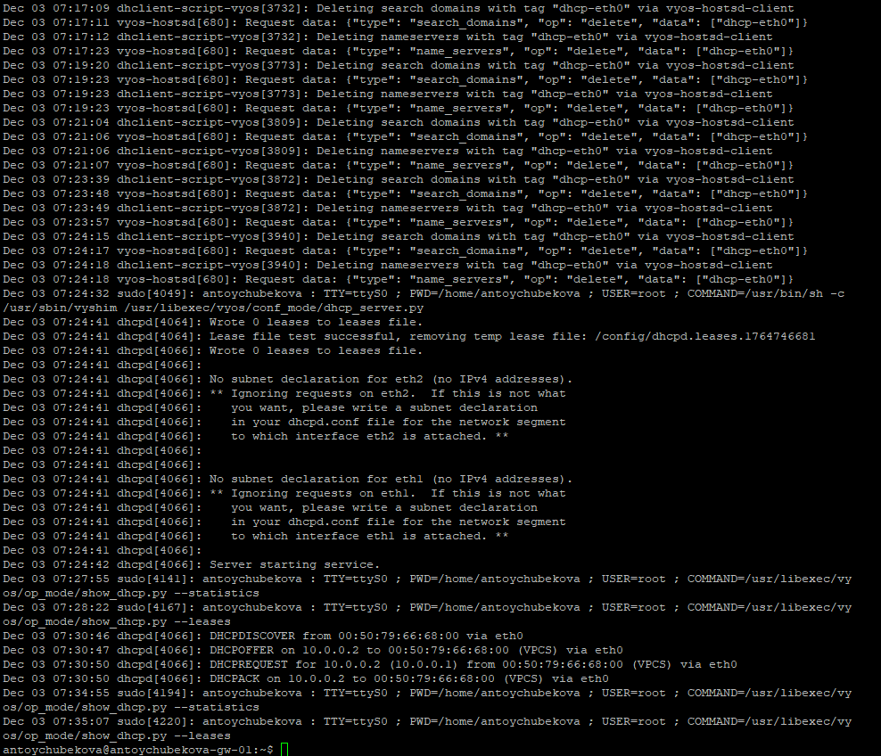

Журнал работы DHCP-сервера

## Настройка DHCP в случае IPv4

Логи показывают работу DHCP-сервера и связанные с ним процессы в системе VyOS. Видно удаление старых DNS-настроек интерфейса eth0, запуск DHCP-демона, проверку конфигурации, а также ключевые события аренды: получение клиентом DHCPDISCOVER, отправку DHCPOFFER, DHCPREQUEST и подтверждение DHCPACK.

## Настройка DHCP в случае IPv4

[figure not shown]

DHCP Discover

## Настройка DHCP в случае IPv4

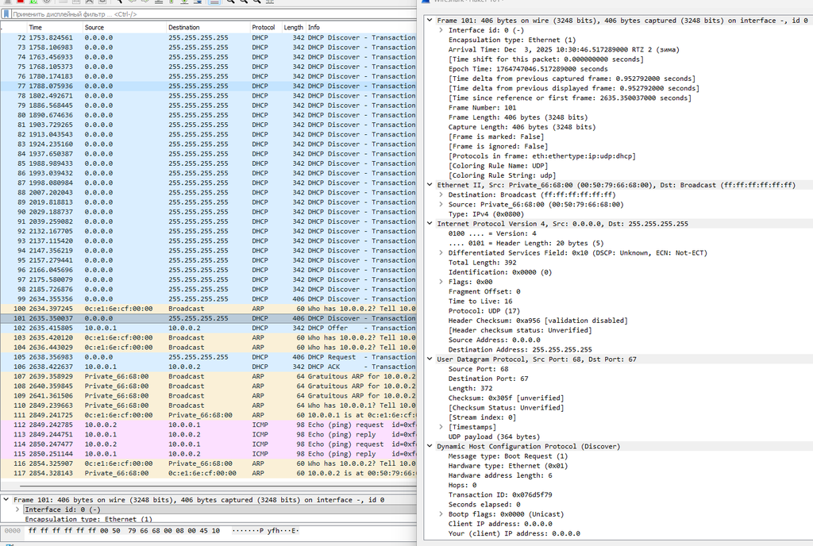

DHCP Discover

## Настройка DHCP в случае IPv4

[figure not shown]

DHCP Offer

## Настройка DHCP в случае IPv4

[figure not shown]

DHCP Request

## Настройка DHCP в случае IPv4

[figure not shown]

DHCP ACK

## Настройка DHCP в случае IPv4

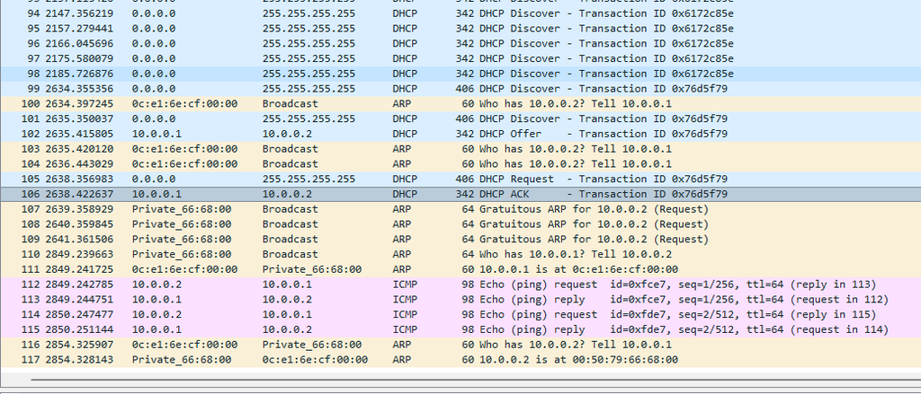

Полный процесс динамического получения IP-адреса клиентом через DHCP

## Настройка DHCP в случае IPv6

В предыдущем проекте в рабочем пространстве дополним сеть, разместив и соединив устройства в соответствии с топологией, приведённой в лабораторной работе. Используем хост (клиент) Kali Linux CLI, поскольку клиент VPCS не поддерживает DHCPv6. Измените отображаемые названия устройств.

[figure not shown]

Добавление Kali Linux CLI

## Настройка DHCP в случае IPv6

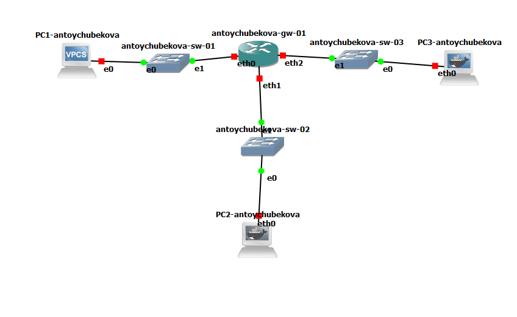

Топология моделируемой сети

## Настройка DHCP в случае IPv6

Включим захват трафика на соединениях между маршрутизатором gw-01 и коммутаторами sw-02 и sw-03.

[figure not shown]

Включение захвата трафика

## Настройка DHCP в случае IPv6

Настроим адресацию IPv6 на маршрутизаторе.

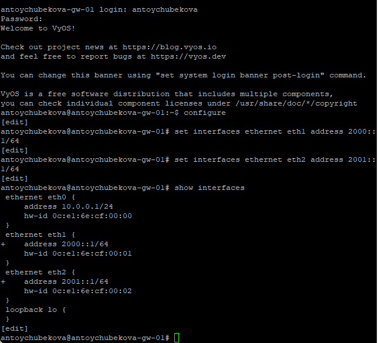

Настройка адресации IPv6

## Настройка DHCP в случае IPv6

Сохраним наши изменения.

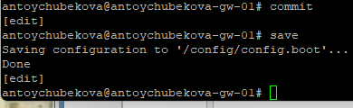

Сохранение изменений

## Настройка DHCP в случае IPv6

На маршрутизаторе настроим DHCPv6 без отслеживания состояния. Настроим объявления о маршрутизаторах (Router Advertisements, RA) на интерфейсе eth1.

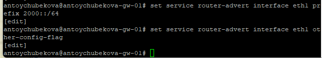

Настройка объявления о маршрутизаторах

## Настройка DHCP в случае IPv6

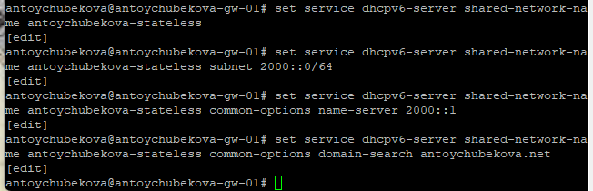

Добавление конфигурации DHCP-сервера

## Настройка DHCP в случае IPv6

Далее сохраняем наши изменения и посмотрим корректность отработки выше команд.

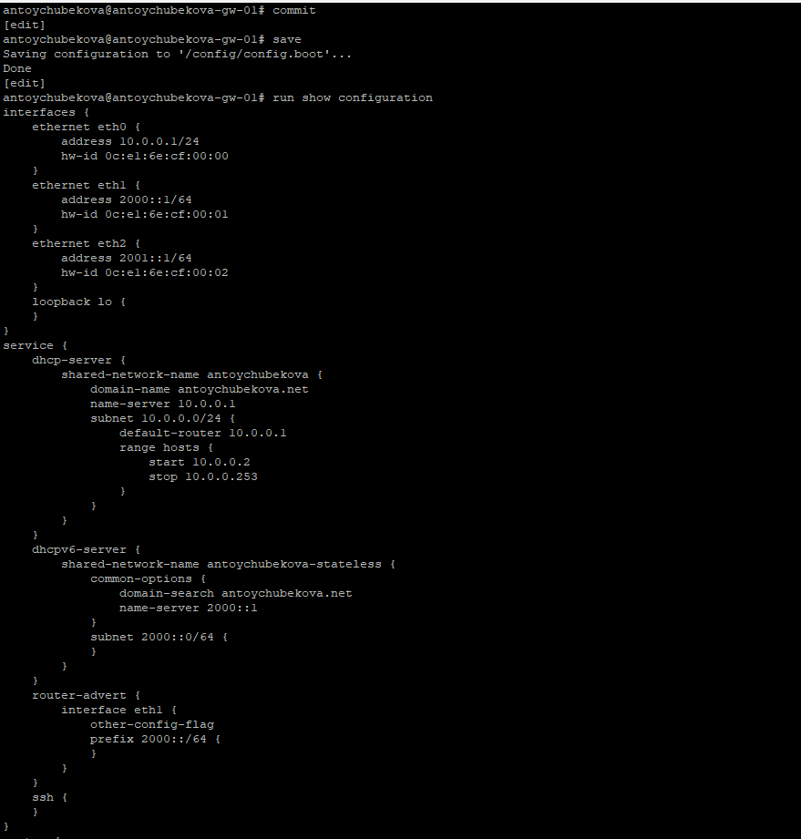

Сохранение и конфигурация